# Part B - Linear Regression Workflow

Ryan Greenup

26 May 2018

# Preamble

Load in the necessary packages and datasets:

```r
#setwd.loadpac()

    if(require('pacman')){
      library('pacman')
    }else{
      install.packages('pacman')
      library('pacman')
    }
```

```r
    pacman::p_load(tidyverse, reshape2, ggplot2, rmarkdown, dplyr, plotly, rstudioapi, wesanderson, RColorBrewer)


  ##Load Dataset
  all.df <- read.csv(file = "practical04b.csv", header = TRUE, sep = ",")

  head(all.df)
```

```
##   X      input    output
## 1 1   6.525006  29021003
## 2 2  29.197010  39938554
## 3 3 104.897110 310171606
## 4 4   7.490008   7571733
## 5 5  75.419083 278974401
## 6 6  93.049239 279107301
```

# The Regression Worklfow (What we are trying to do)

In order to fit a model to the data, it is necessary to use the following workflow:

1. Fit a model to a subset of the data, call this subset the training data. (this step is known as training the model)
- create multiple models
2. Validate the performance of the various models using another set of data (called the validation data)
- the model that has the lowest validation error (regardless of the error from the training data), is the appropriate model.
3. Assess the performance of the selected model using another set of data. (called the test data)

# Splitting the Data

## Set the Seed

Setting the seed allows R to produce random numbers that will be consistent across like scripts, it is analogous to remembering which column and row random numbers are drawn from a table.

```r
set.seed(3141)
```

## Splitting the Data

There are two common ways to work with training, validation and test sets, depending on how much data is available:

- Cross-Validation
- Random Subsets

Where there is insufficient data, cross-validation may be employed, in this case we will perform a random split of the data:

```r
##So we want to create 3 random samples of data

  N     <- nrow(all.df)
  idval <- sample(N)

  train.ID <- idval[0:(N*0.5)]
  val.ID   <- idval[((N*0.5)+1):(N*0.75)]
  test.ID  <- idval[((N*0.75)+1):N]

  train.df <- all.df[train.ID,]
  val.df   <- all.df[val.ID,]
  test.df  <- all.df[test.ID,]


      #Order the Data Frame
      train.df <- train.df[order(train.df$X),]
      val.df   <- val.df[order(val.df$X),]
      test.df  <- test.df[order(test.df$X),]
```

# Visualise the Data

It isn’t always possible to visualise the data, however where it is possible it should be done.

In this case the data is only two-dimensional so it can be easily visualised:

```r
# Visualise the Data ------------------------------------------------------

  ##This isn't always possible but in this case it is
  all.df$sample            <- FALSE
  all.df[train.ID,]$sample <- "train"
  all.df[val.ID,]$sample   <- "val"
  all.df[test.ID,]$sample  <- "test"

 head(all.df)
```

```
##   X      input    output sample
## 1 1   6.525006  29021003    val
## 2 2  29.197010  39938554   test
## 3 3 104.897110 310171606   test
## 4 4   7.490008   7571733   test
## 5 5  75.419083 278974401   test
## 6 6  93.049239 279107301  train
```

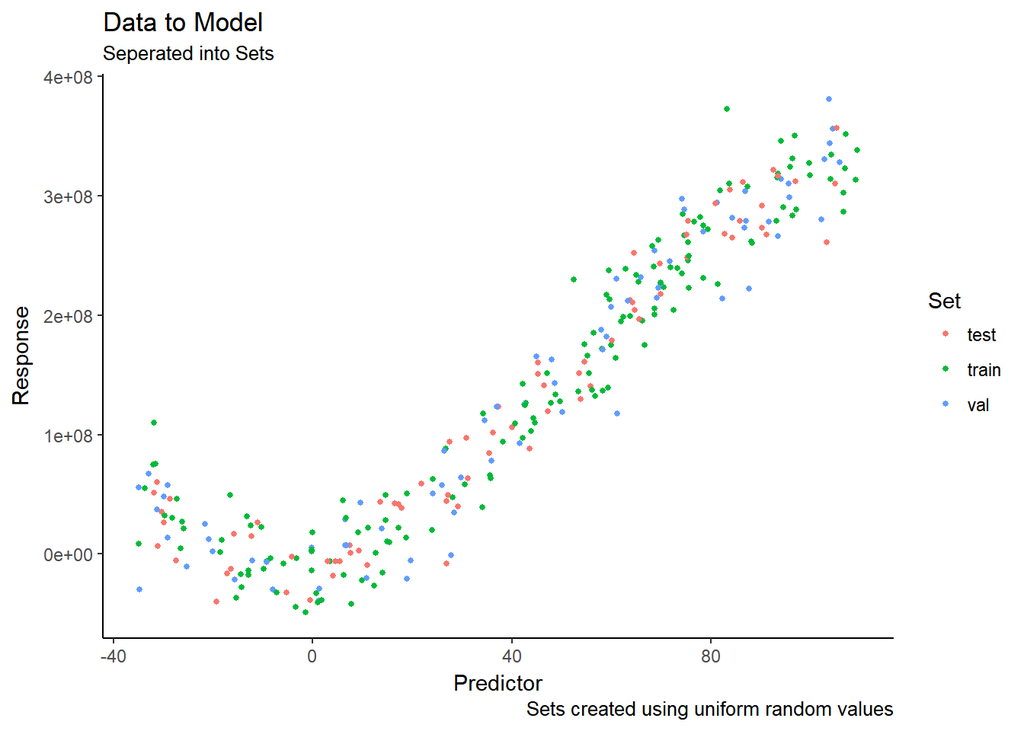

```r
 all.plot <- ggplot(all.df, aes(x = input)) +
   geom_point(data = all.df, size = 1, aes(y = output, col = sample)) +
   theme_classic() +
   labs(x = "Predictor", y = "Response", col = "Set", title = "Data to Model",
        subtitle = "Seperated into Sets",
        caption = "Sets created using uniform random values")
 #  scale_color_brewer(palette="Pastel2")

 all.plot
```

# Model Training

Training a model refers to fitting models to the set of training data.

We don’t know which model will be appropriate for this data, but the data appears to have a natural curve so we will fit a few polynomial models and see how they perform.

It would be wise to create these models through a loop (because it would prevent inconsistent errors and make it possible to produce large numbers of models) however that is a little tricky to do for models so for now that will be left.

*Be aware, that when making models `~I(X^n)` or `~ poly(x, n)` can both be used, it has something to do with correlated coefficients and orthogonal coefficients; but I couldn’t figure out which to use and why.*

```r
# Train a Model -----------------------------------------------------------

  #train models of varying complexity
 # attach(train.df)
 head(train.df)
```

```
##     X      input    output
## 6   6  93.049239 279107301
## 9   9  68.625796 200200695
## 10 10  -3.239293  -3428366
## 12 12  28.081122  47764570
## 13 13 104.135610 334400319
## 16 16 -14.197866 -27757917
```

```r
 mod.lm <- lm(output ~ input, data = train.df)
 mod.p2 <- lm(output ~ I(input^2) + input ,data = train.df)
 mod.p3 <- lm(output ~ I(input^3) + I(input^2) + input, data = train.df)
 mod.p4 <- lm(output ~ I(input^4) + I(input^3) + I(input^2) + input, data = train.df)
 mod.p5 <- lm(output ~ I(input^5) + I(input^4) + I(input^3) + I(input^2) + input, data = train.df)
 mod.p6 <- lm(output ~ I(input^6) + I(input^5) + I(input^4) + I(input^3) + I(input^2) + input, data = train.df)
 mod.p7 <- lm(output ~ I(input^7) + I(input^6) + I(input^5) + I(input^4) + I(input^3) + I(input^2) + input, data = train.df)
```

From these models create a dataframe of prediction values for the models and throw it all into a list to store it for now:

```r
 #Create Predictions and throw everything into a list
 train.df <- data.frame(train.df,
                        mod_lm = predict(mod.lm),
                        mod_p2 = predict(mod.p2),
                        mod_p3 = predict(mod.p3),
                        mod_p4 = predict(mod.p4),
                        mod_p5 = predict(mod.p5),
                        mod_p6 = predict(mod.p6),
                        mod_p7 = predict(mod.p7)
                        )[order(train.df$X),]

 train.mod.df <- melt(data = train.df, id.vars = c("X", "input", "output"))

  train.mod.list <- list(mod.lm, mod.p2, mod.p3, mod.p4, mod.p5, mod.p6, mod.p7)

  training.list <- list(models = train.mod.list, training_data = train.df, model_predictions = train.mod.df )
```

Now we can visualise these models, but first we will fit some pretty colours:

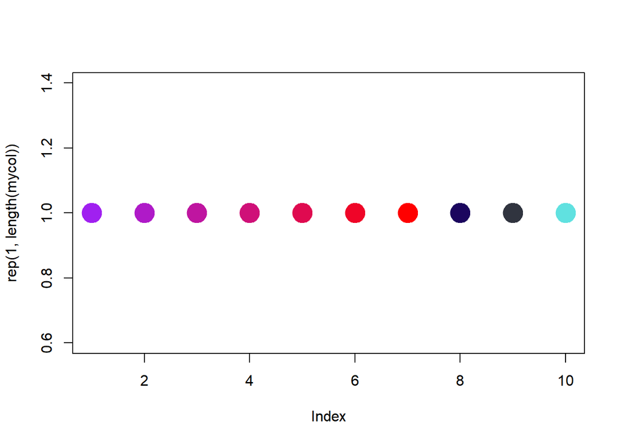

```r
#Visualise the Models
    ##Create label and colour vectors
     plot.labels <- c("Linear Model", "Quadratic", "Cubic", "4th Order",
                  "5th Order", "6th Order", "7th Order",
                  "Test Set", "Training Set", "Validation Set")

     colfunc <- colorRampPalette(c("purple", "Red"))
     mycol <- c(colfunc(7), "#1B065E", "#30343F", "#60E1E0")
     plot(rep(1,length(mycol)),col=mycol,pch=19,cex=3)
```

The colours seem reasonable so we will use them for our plot:

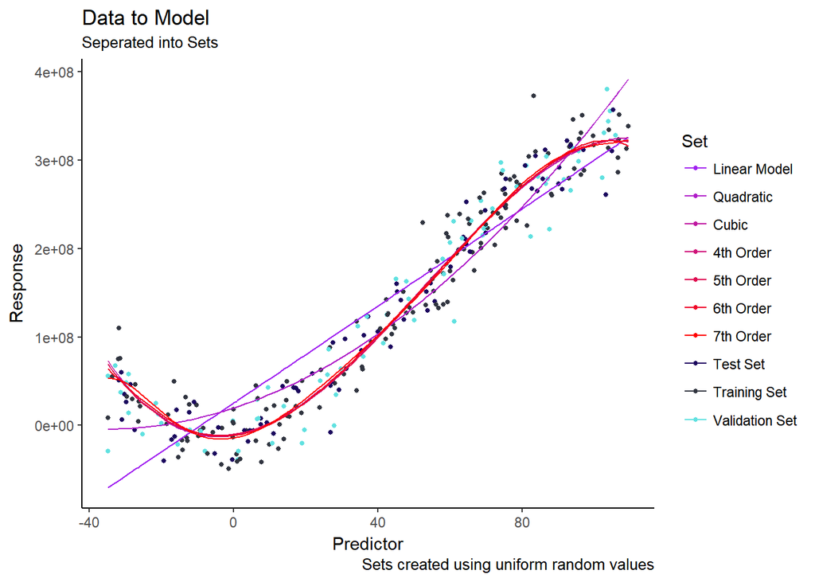

```r
##Plot the models over the Data
      all.plot +
        geom_line(data = train.mod.df, aes(x = input, y = value, col = variable)) +
        scale_color_manual(values = mycol, labels = plot.labels)
```

# Loss Functions, Error and Model selection

So it can be seen that there are a few models, that appear to predict (not necessarily forecast) the data quite well. In order to select which model is appropriate, we will use the Root Mean Square Error $\left( RMSE = \sqrt{ ( \frac{1}{n}\sum_{i=1}^{n}[(y_i-\hat{y_i})^2] } \right)$ which is a predictor of the average error from data point to model.

So it is necessary to calculate and plot the validation error and training error in order to decide on the most appropriate model.

## Training Error

The training Error provides a benchmark to understand the validation error, it can be calculated thusly:

```r
train.rmse.lm <- sqrt(sum((train.df$output-predict(mod.lm, newdata = train.df))^2)/nrow(train.df))
```

Scrictly speaking there is no cause to specify the newdata in the call to predict, the predict function will use the input data that was used to create the model to predict model values where ‘newdata’ is not specified. I have specified the parameter here, so later, when I create a for loop and function, I don’t forget the need to specify the input data.

### Create a function

Because:

1. A mistake may be made in writing out the RMSE for other sets
- mistakes could be inconsistent
2. It is incompatible with loops
3. It is labour intensive

A function will be used to calculate the RMSE:

```r
rmse <- function(dframe, model){

    y     <- dframe[,names(dframe) == "output"]
    y.hat <- predict(object = model, newdata = dframe)
    resid <- y-y.hat
    RSS   <- sum(resid^2)
    T.Error <- RSS/nrow(dframe)
    RMSE <- sqrt(T.Error)

       return(RMSE)
  }
```

### Create a loop

Now we can use a loop to calculate the RMSE Values, this is important because:

1. For a large number of models, it won’t be possible to write out every line (even with a function to expedite the process)
2. It increases the probability of a transcription error, a loop isn’t immune to errors, but at least they will be consistent and easily rectified.

#### Create an empty data frame

Before executing the loop a data frame to store values will need to be created. Where possible a fixed static vector or data frame should be used within a loop because it will execute much faster than a dynamic vector that grows with each repetition, this can require some forethought but will lead to more efficient execution.

```r
##Use a for loop to calculate all RMSE Values
    ##Create a data frame to store the values
       error.df <- data.frame(matrix(
         ncol = 4, nrow = length(training.list$models)))
       colnames(error.df) <- c("Order",
                               "Training Error",
                               "Validation Error",
                               "Test Error")
```

#### Execute the loop

```r
    ##Execute the loop
  for (i in 1:length(train.mod.list)) {

    rmse.val <- rmse(train.df, training.list$models[[i]])
  error.df[i,] <- c(order = i,
                    training_error = rmse.val,
                    validation_error = NA,
                    test_error = NA)

  if (i==length(train.mod.list)) {
    print(head(error.df))
  }

  }
```

```
##   Order Training Error Validation Error Test Error
## 1     1       47168577               NA         NA
## 2     2       37817753               NA         NA
## 3     3       26004785               NA         NA
## 4     4       25963398               NA         NA
## 5     5       25962156               NA         NA
## 6     6       25907613               NA         NA
```

## Validation Error

Calculating the validation error is now simply a process of specifying the validation data frame `val.df` rather than the training data frame.

```r
# Calculate the Validation Errors -----------------------------------------

  ##Use a for loop to calculate all validation error values

    #use the error.df data frame from before
  for(i in 1:7){
    rmse.val <- rmse(val.df, training.list$models[[i]])
    error.df[i,3] <- rmse.val

    if (i==length(train.mod.list)) {
    print(head(error.df))
  }

  }
```

```
##   Order Training Error Validation Error Test Error
## 1     1       47168577         49517836         NA
## 2     2       37817753         36797112         NA
## 3     3       26004785         29586385         NA
## 4     4       25963398         29620189         NA
## 5     5       25962156         29688027         NA
## 6     6       25907613         29604562         NA
```